# Machine Learning in Biology: A scikit-learn Tutorial

## Machine learning

Machine learning is a powerful tool, that nowadazs is in everyones Mind. With the latest breakthroughs in image generation, detection and manipulation as well as in large langauge modeling, it gained coverage in mainstream media and is now considered a topic overarcing key technology by policy makers in all aspects of modern life. (Large parts of these Notebook were written with the help of Mistral! Credit where it's due I'd say :D While it could not write the thing for me, it shortened the time by at least half, much likely more, very usefull! :) )

In science it is considered as such for a longer time and it's roots are way back. In a sense machine learning is applied statistics, that focus more on iteratively improving models, that learning about the models themselves or their mathematical bounds.

Machine learning algorithms can be broadly categorized into three paradigms: supervised learning, unsupervised learning and reinforcement learning. We will not handle reinforcement learning in this course but focus on the other two. Unsupervised learning tries to uncover patterns or functions in the data, that arise from the features themseves, without any additional information. We will see unsupervised learning techniques in the form of clustering algorithms and dimension reduction. In supervised learning, the algorithm is trained on labeled data, where each data point is associated with a target variable. The goal is to learn a mapping between the input features and the target variable, so that the algorithm can make predictions on new, unseen data. This is basically approximating a function projects the features onto the target space.

## Data Loading and Preprocessing

We'll start by loading our data, which consists of four CSV files holding normalized expression data for various genes. We added another two datasets, of another Cancer! We'll ;earn how to classify tumors and healthy in each tossue and we'lll also see, that we can easily classify which tissue we are looking at. Each CSV file has the same structure, with the first column being an ID, the second column being the class (Tumor or Normal), and the subsequent columns being gene expression data. We'll add the dataset class here as well as the tumor class.

Here's how you can load and preprocess your data:

```python
import pandas as pd
import os

# Specify the path to the folder containing the CSV files
folder_path = 'data'

# Use os to get a list of all files in the folder
files = os.listdir(folder_path)

# Filter the list to only include CSV files
files = [file for file in files if file.endswith('.csv')]

# cancer type information
# note: this trick only works, because we now the order of the files :)
cancer_dataset = dict(zip(files, ["HNC", "HNC", "BRC", "BRC"]))

# List to hold data frames
dfs = []

# Loop through each file
for file in files:
    # Create the full file path
    file_path = os.path.join(folder_path, file)
    # Read in the data and add a 'dataset' column with the file name
    df = pd.read_csv(file_path).assign(dataset=file).assign(tumor_type=cancer_dataset[file])
    # Add the data frame to the list
    dfs.append(df)

# Concatenate all data frames into one
df = pd.concat(dfs, ignore_index=True)
df = df.set_index("ID")

df.head()
```

| ID | class | ENSG00000000003 | ENSG00000000005 | ENSG00000000419 | ENSG00000000457 | ENSG00000000460 | ENSG00000000938 | ENSG00000000971 | ENSG00000001036 | ENSG00000001084 | ... | ENSG00000285987 | ENSG00000285988 | ENSG00000285989 | ENSG00000285990 | ENSG00000285991 | ENSG00000285992 | ENSG00000285993 | ENSG00000285994 | dataset | tumor_type |
| --- | --- | --- | --- | --- | --- | --- | --- | --- | --- | --- | --- | --- | --- | --- | --- | --- | --- | --- | --- | --- | --- |
| SRR1754117 | Tumor | 11.093040 | 2.969844 | 9.990933 | 9.452693 | 7.986177 | 9.782317 | 13.648825 | 11.115678 | 10.310412 | ... | 3.015522 | 2.131915 | 2.131915 | 2.131915 | 4.995241 | 2.131915 | 2.131915 | 3.363149 | GSE64912.csv | HNC |
| SRR1754118 | Tumor | 10.929458 | 3.070538 | 9.800101 | 9.491018 | 8.397969 | 9.329050 | 13.754111 | 10.134869 | 10.026614 | ... | 2.131915 | 2.131915 | 2.131915 | 2.131915 | 5.312684 | 2.131915 | 2.131915 | 3.701540 | GSE64912.csv | HNC |
| SRR1754119 | Tumor | 11.463203 | 2.687601 | 9.814206 | 9.852032 | 7.969095 | 8.044819 | 13.755808 | 10.882487 | 10.463199 | ... | 2.956442 | 2.131915 | 2.131915 | 2.131915 | 5.694262 | 2.718716 | 2.131915 | 2.718764 | GSE64912.csv | HNC |
| SRR1754120 | Tumor | 10.764904 | 4.287089 | 9.850854 | 9.293921 | 7.428099 | 8.031387 | 12.805946 | 10.987034 | 10.183807 | ... | 2.766204 | 2.131915 | 2.131915 | 2.131915 | 6.048311 | 2.131915 | 2.131915 | 3.021964 | GSE64912.csv | HNC |
| SRR1754121 | Tumor | 11.609858 | 3.281690 | 10.259462 | 10.125975 | 8.132683 | 7.441034 | 12.175295 | 10.790123 | 10.029304 | ... | 2.750876 | 2.131915 | 2.131915 | 2.131915 | 5.299987 | 2.131915 | 2.131915 | 2.131915 | GSE64912.csv | HNC |

5 rows × 58738 columns

Now that we have our data loaded and preprocessed, let's move on to the next step: normalization and scaling.

## Normalization and Scaling

Before we start with the machine learning part, it's important to discuss normalization and scaling. These are crucial steps in preprocessing data for machine learning models. They ensure that each feature contributes proportionately to the final distance, which can improve the performance of some machine learning algorithms.

Scaling and normalization are sometimes used interchangeably, but they refer to different things. There is no "official" definition, but here we'll use the fiollowing: Scaling is the process of changing the range of the data, while normalization is the process of changing the shape of the distribution of the data.

In scaling, we typically transform the data to have a certain range, such as [0, 1] or [-1, 1]. This is useful when the features have different units or scales, and we want to ensure that each feature contributes equally to the final distance.

In normalization, we transform the data to have a specific distribution, such as a Gaussian distribution with mean 0 and standard deviation 1. This is useful when the absolute values of the features are not important, but their relative values are. Normalization can also help to reduce the effects of outliers.

In our case, the data has been pre-processed and normalized using DESeq2's vst method. This method transforms the count data to a common scale, allowing for comparisons across samples. Since our data is already normalized, we might not need to scale it. However, it's still a good practice to check whether scaling is necessary. And since we also plan to combine multiple datasets, that otherwise have a strong batch effect (as we saw already in the gene expression part), we'll additionally use the standard scaler. This actually scales the data AND applies a normalization, as we see, bot the range of the data and its distribution changing.

Here's how you can check the distribution of your data:

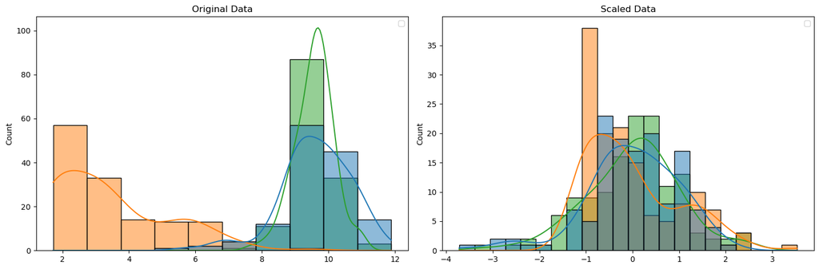

```python
import seaborn as sns
import matplotlib.pyplot as plt
from sklearn.preprocessing import StandardScaler

# Select a few columns for visualization
columns_to_visualize = ['ENSG00000000003', 'ENSG00000000005', 'ENSG00000000419']

# Create a DataFrame with only the selected columns
df_selected = df[columns_to_visualize]

# Create a figure with 3 subplots
fig, axs = plt.subplots(1, 2, figsize=(15, 5))

# Flatten the array of axes for easier indexing
axs = axs.flatten()

# Plot the original data with coloring for tumor types
sns.histplot(data=df_selected, ax=axs[0], kde=True)
axs[0].set_title('Original Data')
axs[0].legend(loc='upper right')

# Create a StandardScaler object
scaler = StandardScaler()

# Fit and transform the data
df_selected_scaled = pd.DataFrame(scaler.fit_transform(df_selected), columns=df_selected.columns)

# Plot the scaled data with coloring for tumor types
sns.histplot(data=df_selected_scaled, ax=axs[1], kde=True)
axs[1].set_title('Scaled Data')
axs[1].legend(loc='upper right')

# Show the plot
plt.tight_layout()
plt.show()
```

As you see, it is possible to plot a histogram with a 'wide' version of the data instead of a 'long'. However, the longer data representation is more versatile: There is a built in function in pandas, that can be used to get a long version of our data: melt(). The long format allows us to use the 'hue' parameter in the histogram function to color our plots.

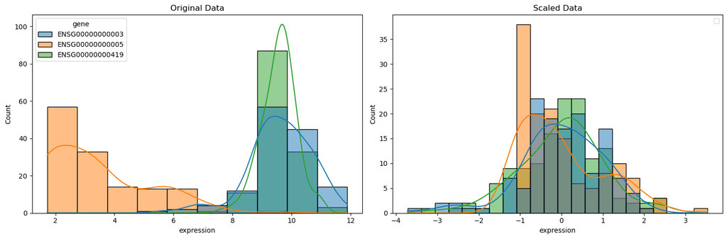

```python
# Select a few columns for visualization
columns_to_visualize = ['ENSG00000000003', 'ENSG00000000005', 'ENSG00000000419']

# Create a DataFrame with only the selected columns and the 'tumor_type' column
df_selected = df[columns_to_visualize + ['tumor_type']]

# Melt the data to long-form
df_long = pd.melt(df_selected, id_vars='tumor_type', var_name='gene', value_name='expression')
# Create a figure with 2 subplots
# It is possible to create as much subplots as you want, here we have a 1 x 2 grid.
# we could also have a 2 x 2 or 10 x 3 grid etc.
fig, axs = plt.subplots(1, 2, figsize=(15, 5))

# Flatten the array of axes for easier indexing (single digit indexing instead of [i,j])
axs = axs.flatten()

# Plot the original data with coloring for tumor types
sns.histplot(data=df_long, x='expression', hue='gene', ax=axs[0], kde=True)
axs[0].set_title('Original Data')
# axs[0].legend(loc='upper right')

# Create a StandardScaler object
scaler = StandardScaler()

# Fit and transform the data
df_selected_scaled = pd.DataFrame(scaler.fit_transform(df_selected.drop('tumor_type', axis=1)), columns=df_selected.columns[:-1])

# Add the 'tumor_type' column back to the scaled data
df_selected_scaled['tumor_type'] = df_selected['tumor_type'].to_list()

# Melt the scaled data to long-form
df_long_scaled = pd.melt(df_selected_scaled, id_vars='tumor_type', var_name='gene', value_name='expression')

# Plot the scaled data with coloring for tumor types
sns.histplot(data=df_long_scaled, x='expression', hue='gene', ax=axs[1], kde=True)
axs[1].set_title('Scaled Data')
# axs[1].legend(loc='upper right')

# Show the plot
plt.tight_layout()
plt.legend(loc='best')
plt.show()
```

#### Exercise 1.0 - Plotting and observing the data

1. Plot different genes (just select some at random and compare how they are distributed)
2. Plot the same plot, but change the coloring to resemble the tumor type.  
   If you are feeling adventurous, try to build a 2 x 2 grid plot and plot the gene coloring in the top row and the tumoir coloring in the bottom.
3. Wopuld it be possible to distinguish the two tissues with the genes you selected?

Although, we do sometimes see a clear difference in distribution, we'll stay with the non-scaled version for now. However, keep in mind that this can have a large impact on the performance of your classifiers. Checking the distribution of your data before making a decision is a good habit in general.

## Clustering

Clustering is an unsupervised learning technique used to group similar data points together. It's a useful tool for exploratory data analysis, as it can help to identify patterns and structures in the data. In this section, we'll perform two types of clustering: k-means and hierarchical clustering. We'll also perform principal component analysis (PCA) to reduce the dimensionality of the data and compare the results of the clustering methods on the complete data.

### K-Means Clustering

K-means clustering is a centroid-based clustering algorithm that aims to partition the data into K distinct, non-overlapping clusters. The algorithm works by initializing K centroids randomly, and then iteratively assigning each data point to the closest centroid and updating the position of the centroids based on the mean of the data points assigned to them.

```
<class 'numpy.int32'>
```

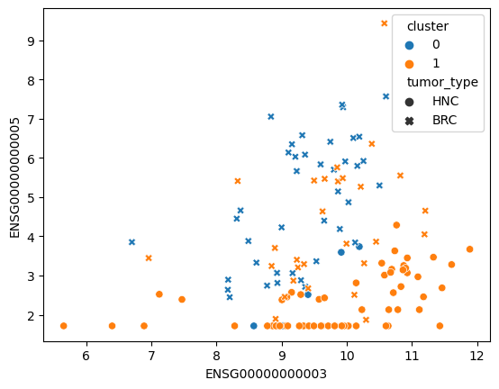

```python
from sklearn.cluster import KMeans

# Select the first three columns for clustering
X = df.iloc[:, 3:5]

# Initialize the KMeans object with 3 clusters
kmeans = KMeans(n_clusters=2)

# Fit the model to the data
kmeans.fit(X)

# Get the cluster labels for each data point
labels = kmeans.labels_
print(type(labels[0]))
# Add the cluster labels to the data frame
df['cluster'] = labels

# Plot the data with coloring for the clusters
sns.scatterplot(data=df, x='ENSG00000000003', y='ENSG00000000005', hue='cluster', style='tumor_type')
plt.show()
```

### Hierarchical Clustering

Hierarchical clustering is a clustering algorithm that builds a hierarchy of clusters by iteratively merging the closest pairs of clusters until only a single cluster remains. The result is a dendrogram, which is a tree-like diagram that shows the hierarchical relationship between the clusters.

Here's how you can perform hierarchical clustering on the mini sub set of our columns of our data:

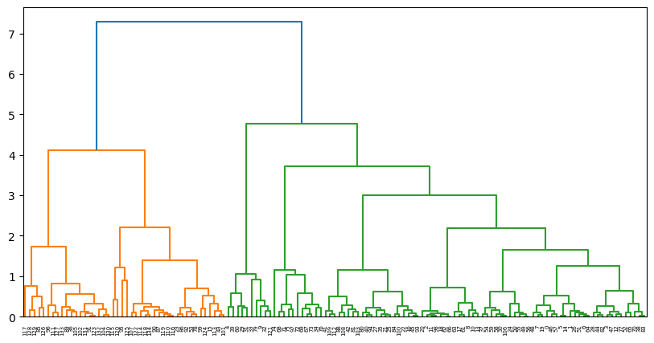

```
<class 'numpy.intc'>
```

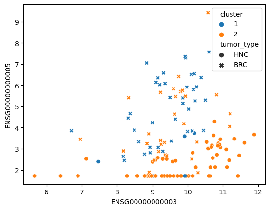

```python
import scipy.cluster.hierarchy as hc

# Select the first three columns for clustering
X = df.iloc[:, 3:5]
# Compute the linkage matrix
linkage_matrix = hc.linkage(X, method='ward')

# Generate the dendrogram
fig = plt.figure(figsize=(10, 5))
dn = hc.dendrogram(linkage_matrix)
plt.show()

# get the clusters, to be able to plot them
labels_hierarchical = hc.fcluster(linkage_matrix, 2, criterion='maxclust')
print(type(labels_hierarchical[0]))
plt_df = df.assign(cluster=labels_hierarchical)

# Plot the data with coloring for the clusters
sns.scatterplot(data=plt_df, x='ENSG00000000003', y='ENSG00000000005', hue='cluster', style='tumor_type', palette="tab10")
plt.show()
```

Above, we use the 'ward' linkage method, which aims to minimize the variance within each cluster. It's one of the more 'modern' methods and works quite well in most cases. However, you can experiment with different methods, such as 'single' or 'complete', to see how they affect the results, this will make more sense iun the next part though.

### PCA and Comparison of Clustering Methods

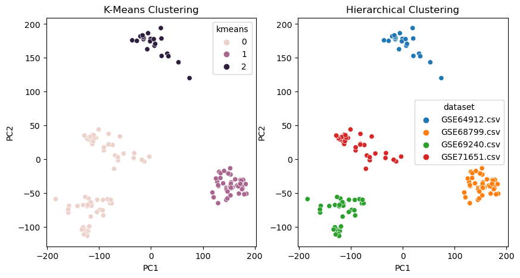

```python
from sklearn.decomposition import PCA

# metadata cols, we'll use them throughout the script.
meta_cols = ["class", "dataset", "tumor_type", "cluster"]

# Perform PCA on the complete data
pca = PCA(n_components=50)

# get the numeric data
X_pca = pca.fit_transform(df.drop(meta_cols, axis=1))

# Perform k-means clustering on the PCA data
kmeans = KMeans(n_clusters=3)
labels_kmeans = kmeans.fit_predict(X_pca)

# Perform hierarchical clustering on the PCA data
linkage_matrix = hc.linkage(X_pca, method='ward')
labels_hierarchical = hc.fcluster(linkage_matrix, 3, criterion='maxclust')

# Create a new data frame with the PCA data and the cluster labels
df_pca = pd.DataFrame(X_pca, columns=['PC' + str(i) for i in range(1, 51)])
df_pca['kmeans'] = labels_kmeans
df_pca['hierarchical'] = labels_hierarchical
df_pca['tumor_type'] = df['tumor_type'].to_list()
df_pca['class'] = df['class'].to_list()
df_pca['dataset'] = df['dataset'].to_list()

# Plot the PCA data with coloring for the clusters
fig, axs = plt.subplots(1, 2, figsize=(10, 5))

# K-means clustering
sns.scatterplot(data=df_pca, x='PC1', y='PC2', hue='kmeans', ax=axs[0])
axs[0].set_title('K-Means Clustering')

# Hierarchical clustering
sns.scatterplot(data=df_pca, x='PC1', y='PC2', hue='dataset', ax=axs[1])
axs[1].set_title('Hierarchical Clustering')

plt.show()
```

It seems, we have a very clear effect to observe here, that has nothing to do with the tissue or tumor class :D

#### Exercise 2 - scaled data

1. Run the PCA again with scaled data and see how this changes the PCA. Check how we used the scaler above and apply it to the complete dataset. Use this as an input to the PCA function and the rest can remain unchanged. Add the df.index to the new scaled dataframe, with the set_index() function. Use the .Join() function, to add the metadata (df[meta_cols]).
2. Observe how the plot has changed, play around with colors and styles and see, if the projection of the data is more sensible now
3. Is there still room for improvement? What could we do about it? Discuss with your fellow students.

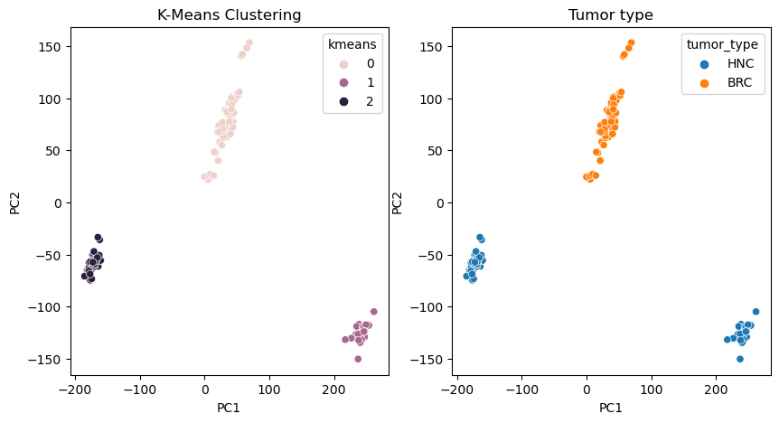

```python
from sklearn.decomposition import PCA

# metadata cols, we'll use them throughout the script.
meta_cols = ["class" ,"dataset" ,"tumor_type" ,"cluster"]
num_cols = df.drop(meta_cols, axis=1).columns

# Perform PCA on the complete data
pca = PCA(n_components=50)

# Exercise 2.1
# build scaled dataframe, you'll need it later!
df_scaled = pd.DataFrame(scaler.fit_transform(df.drop(meta_cols, axis=1)), columns=df.drop(meta_cols, axis=1).columns)
df_scaled = df_scaled.set_index(df.index)
df_scaled = df_scaled.join(df[meta_cols])

# get the numeric data
X_pca = pca.fit_transform(df_scaled.drop(meta_cols, axis=1))

# Perform k-means clustering on the PCA data
kmeans = KMeans(n_clusters=3)
labels_kmeans = kmeans.fit_predict(X_pca)

# Perform hierarchical clustering on the PCA data
linkage_matrix = hc.linkage(X_pca, method='ward')
labels_hierarchical = hc.fcluster(linkage_matrix, 3, criterion='maxclust')

# Create a new data frame with the PCA data and the cluster labels
df_pca = pd.DataFrame(X_pca, columns=['PC' + str(i) for i in range(1, 51)])
df_pca['kmeans'] = labels_kmeans
df_pca['hierarchical'] = labels_hierarchical
df_pca['tumor_type'] = df['tumor_type'].to_list()
df_pca['class'] = df['class'].to_list()
df_pca['dataset'] = df['dataset'].to_list()

# Plot the PCA data with coloring for the clusters
fig, axs = plt.subplots(1, 2, figsize=(10, 5))

# K-means clustering
sns.scatterplot(data=df_pca, x='PC1', y='PC2', hue='kmeans', ax=axs[0])
axs[0].set_title('K-Means Clustering')

# Hierarchical clustering
sns.scatterplot(data=df_pca, x='PC1', y='PC2', hue='tumor_type', ax=axs[1])
axs[1].set_title('Tumor type')

plt.show()
```

## Feature selection

Feature selection is the process of selecting a subset of relevant features for use in model construction. It can be very important for machine learning applications, as it can improve the accuracy and interpretability of the models, as well as reduce the computational cost of training them. In this section, we'll discuss two feature selection methods, one very simple and one more sophisticated, based on a macgine learning model itself: variance filtering and LASSO.  
We'll use the feature selection on the non-scaled data!

### Variance Filtering

Variance filtering is a simple feature selection method that removes features with low variance. The idea behind this method is that features with low variance are unlikely to be informative, as they don't vary much across the samples.  
https://scikit-learn.org/stable/modules/generated/sklearn.feature_selection.VarianceThreshold.html#sklearn.feature_selection.VarianceThreshold

```python
from sklearn.feature_selection import VarianceThreshold

# Initialize the VarianceThreshold object with a variance threshold of 0.1
variance_threshold = VarianceThreshold(threshold=1.5)

# Fit the model to the data and transform the data
X_filtered = variance_threshold.fit_transform(df.drop(meta_cols, axis=1))

# Get the names of the remaining features
feature_names = df.drop(meta_cols, axis=1).columns[variance_threshold.get_support()]

# Print the number of remaining features
print(f'Number of remaining features: {X_filtered.shape[1]}')
```

```
Number of remaining features: 9573
```

### LASSO

Least absolute shrinkage and selection operator (LASSO) is a regression-based feature selection method that adds a penalty term to the loss function, which encourages the model to assign zero coefficients to irrelevant features. In the context of feature selection, we can use LASSO to identify genes that are associated with the tumor/normal classification.

See: https://scikit-learn.org/stable/modules/linear_model.html#lasso

To perform the feature selection with LASSO, we applz it as we would when using it for classification:  
For this we'll need a target variable *y*, that resembles the tumor type. Later we'll build classifiers for both the tumor type as well as the class, but here we'll use the tumor type for selecttion, as this is likely the "stronger" variable, more changes between the different tissues than between healthy and cancerous tissues. We expect, that using this to filter for more impactful features, will also weed out features that are not impactful for the differences between classes, but we cannot know this for sure of course. In reality such problems are not super common and more related to the batch effect aspects we already mentioned. However, in real life, we'd likely run multiple experiments with different classifiers and targets, to be able to better assess the data, also we'd likely split the problem into two and have one dataset with a designated feature selection and preprocessing pipeline per Problem.

We'll need to transform our target variable into a numeral, as to enable scikit-learn to use it. Luckyly scikit learn provides a solution already:  
https://scikit-learn.org/stable/modules/generated/sklearn.preprocessing.LabelEncoder.html

```python
from sklearn.linear_model import LassoCV
from sklearn.preprocessing import LabelEncoder

# Split the data into input (X) and output (y) variables
X = df.drop(meta_cols, axis=1)

# init and fit labelencoder
le = LabelEncoder()
le.fit(df["tumor_type"])

y = le.transform(df['tumor_type'])

# Fit a LASSO model to the data
lasso = LassoCV(alphas=[0.01, 0.1, 1.0], cv=5)
lasso.fit(X, y)

# Get the coefficients of the model
coef = lasso.coef_

# Select the genes with non-zero coefficients
selected_genes = X.columns[coef != 0]

# Print the number of selected genes
print(f"Number of selected genes: {len(selected_genes)}")
```

```
Number of selected genes: 55
```

#### Exercise 3 - Feature selection

1. Try out multiple variance thresholds
2. Optional: The LASSO seems to be quite stringent from the get-go! If you have the time, check the distribution of some of the genes, that are left after selection.
3. Visualize the selected features of LASSO with a heatmap. Seaborn features a heatmap() and a clustermap() function, which would be more appropriate? Which has more functionality? Do we want to annotate the heatmap with additional information for example, which? try both scaled and non-scaled DFs
4. Set the variance low enough to be comparable and make another heatmap from the features selected by variance threshold.

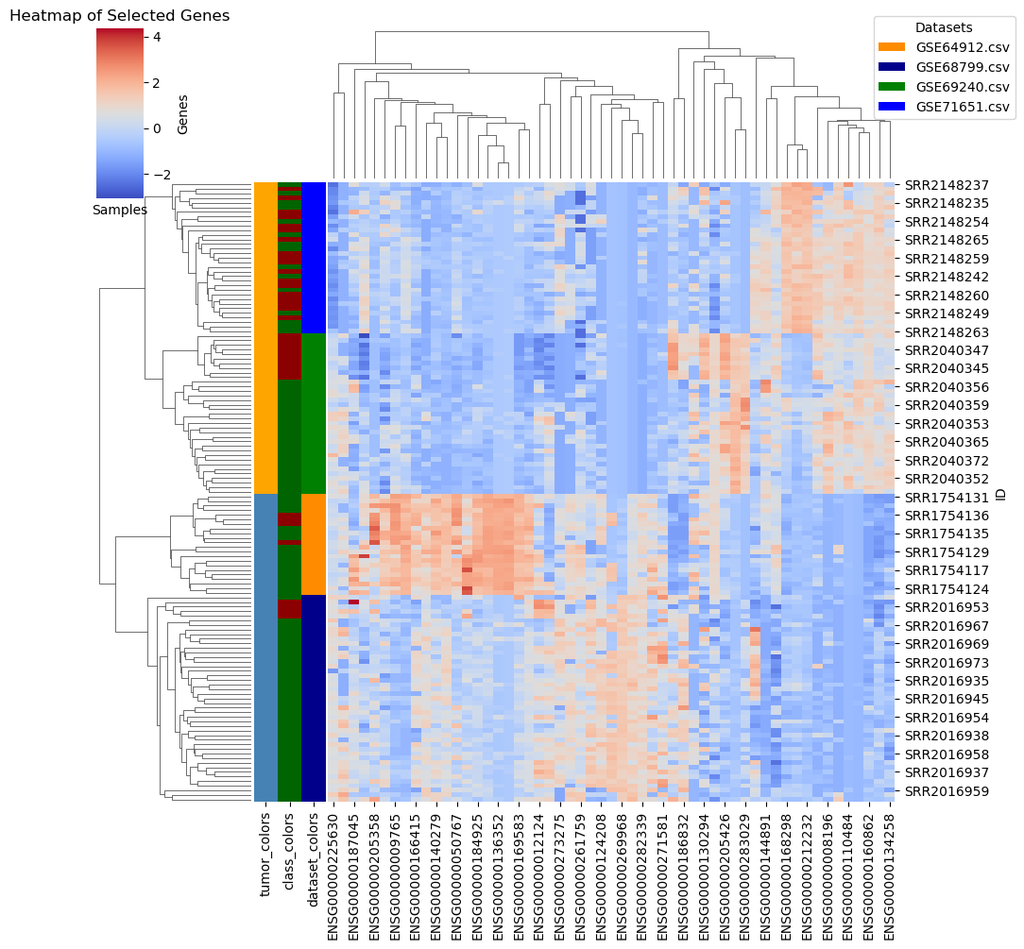

```python
import seaborn as sns
import matplotlib.pyplot as plt
from matplotlib.patches import Patch

# addd color to annotate metadata
lut = dict(zip(df_scaled.tumor_type.unique(), ["steelblue", "orange"]))
tumor_colors = df_scaled.tumor_type.map(lut)
lut = dict(zip(df_scaled["class"].unique(), ["darkgreen", "darkred"]))
class_colors = df_scaled["class"].map(lut)
lut = dict(zip(df_scaled.dataset.unique(), ["darkorange", "darkblue", "green", "blue"]))
dataset_colors = df_scaled.dataset.map(lut)
# this can be used as input for one of the mentioned functions!
color_dataframe = pd.DataFrame({"tumor_colors":tumor_colors, "class_colors":class_colors, "dataset_colors":dataset_colors})


# Create a heatmap of the gene expression data for the selected genes
sns.clustermap(df_scaled[selected_genes], cmap='coolwarm', row_colors=color_dataframe)

# Add labels to the heatmap
plt.title('Heatmap of Selected Genes')
plt.xlabel('Samples')
plt.ylabel('Genes')
plt.xticks(rotation=90)

# add legende for row_colors of datasets
handles = [Patch(facecolor=lut[name]) for name in lut]
plt.legend(handles, lut, title='Datasets',
           bbox_to_anchor=(1, 1), bbox_transform=plt.gcf().transFigure, loc='upper right')

# Show the plot
plt.show()
```

## Classifiers and Regressors

There are two main types of supervised learning: classification and regression. In classification, the target variable is categorical, and the goal is to predict the class label for each input. For example, given a set of gene expression data, we might want to predict whether a sample is cancerous or non-cancerous. In regression, the target variable is continuous, and the goal is to predict a numerical value. For example, given a set of patient data, we might want to predict their age or blood pressure.

### Logistic Regression

Logistic regression is a simple but popular classification algorithm that models the probability of a sample belonging to a particular class. It uses a logistic function to transform the output of a linear model into a probability value between 0 and 1. The logistic function has an S-shaped curve that asymptotes at 0 and 1, making it well-suited for modeling binary outcomes. The function os also often termed "Sigmoid" function: $$ \sigma(x) = \frac{1}{1 + e^{-x}} $$ Below, I plotted it to show, what I am talking about. notice the bounds of the function in *y* are 0 and 1!

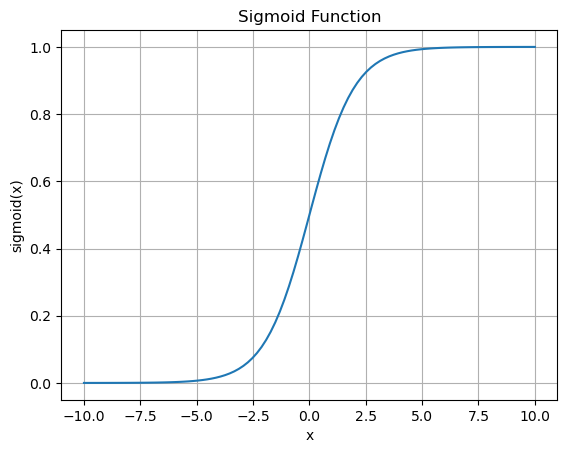

```python
import numpy as np
import matplotlib.pyplot as plt

def sigmoid(x):
    return 1 / (1 + np.exp(-x))

x = np.linspace(-10, 10, 100)
y = sigmoid(x)

plt.plot(x, y)
plt.title('Sigmoid Function')
plt.xlabel('x')
plt.ylabel('sigmoid(x)')
plt.grid(True)
plt.show()
```

Logistic regression is a simple yet powerful algorithm that can handle both linear and non-linear decision boundaries. It is also relatively fast to train and can be easily regularized to prevent overfitting.

#### Exercise 4 - Logistic regression and train test splits

1. Below, we want to filter our data to only use BRC samples. Use .loc and get a boolean vector by calling df["tumor_type"] == "BRC".
2. Use sklearn's train_test_split function to get a dataset for training and one for testing your trained model. Why is it important to test the model on unseen data?

```python
from sklearn.linear_model import LogisticRegression
from sklearn.model_selection import train_test_split

# Exercise 4.1
# filter data to only use BRC
df_brc = df_scaled.loc[df_scaled['tumor_type'] == 'BRC']

# init and fit labelencoder
le = LabelEncoder()

# Split the data into input (X) and output (y) variables
X = df_scaled.drop(meta_cols, axis=1)
y = le.fit_transform(df_scaled["class"])

# make train test split
X_train, X_test, y_train, y_test = train_test_split(X, y, test_size=0.3, random_state=42)


# Initialize the LogisticRegression object
logreg = LogisticRegression()

# Fit the model to the data
logreg.fit(X_train, y_train)

# Make predictions on new data
predictions = logreg.predict(X_test)
print(predictions)
print(y_test)
```

```
[1 0 1 0 1 1 1 1 1 0 1 1 1 1 1 1 1 1 1 1 1 1 1 1 1 1 1 1 1 1 1 1 1 1 0 1 0
 1 0 1 1]
[1 0 0 0 1 1 1 1 0 0 1 1 1 1 0 1 1 1 1 1 1 1 1 1 1 0 1 1 0 1 1 1 1 1 0 1 0
 0 0 1 1]
```

### Random Forests

Random forests are a so called ensemble learning method that combines multiple decision trees (weak classifiers) to improve predictive accuracy (and get a strong classifier). A decision tree is a flowchart-like structure where each internal node represents a test on an input feature, each branch represents the outcome of the test, and each leaf node represents a class label. Random forests work by building many decision trees on random subsets of the data (a process called bagging), and then aggregating their predictions through voting or averaging.

Random forests are known for their high accuracy, robustness to noise and outliers, and ability to handle both categorical and numerical data. They can also provide innate feature importance scores, which are derived by their test criterion and can be useful for feature selection and interpretation. Still, they can be computationally expensive to train and may not perform well on high-dimensional data with few samples, which is a caveat they share with most machine learning algos though.

```python
from sklearn.ensemble import RandomForestClassifier
# we use the same training set as above

# Initialize the RandomForestClassifier object
rfc = RandomForestClassifier(n_estimators=100, random_state=42)

# Fit the model to the data
rfc.fit(X_train, y_train)

# Make predictions on new data
predictions = rfc.predict(X_test)
print(predictions)
print(y_test)
```

```
[1 0 1 0 1 1 1 1 1 0 1 1 1 1 1 1 1 1 1 1 1 1 1 1 1 1 1 1 1 1 1 1 1 1 0 1 0
 1 0 1 1]
[1 0 0 0 1 1 1 1 0 0 1 1 1 1 0 1 1 1 1 1 1 1 1 1 1 0 1 1 0 1 1 1 1 1 0 1 0
 0 0 1 1]
```

## Performance metrics and optimizing your models

When comparing models, we'll need some metrics to measure how well they are doing. There are a plethora of these and the most frequantly used is likely the accuracy, since it is quiate intuitive: $$Accuracy = (TP + TN) / (TP + TN + FP + FN)$$

- TP: True Positives (correctly predicted positive instances)
- TN: True Negatives (correctly predicted negative instances)
- FP: False Positives (incorrectly predicted as positive instances)
- FN: False Negatives (incorrectly predicted as negative instances) So it comes down to all correct predictions divided by N. For a better understanding of what a true and false positive is, we can look at a coinfusion matrix:

[figure not shown]

*A simple confusion matrix, taken from my master thesis.*

However, accuracy is sometimes not the best performance metric, as it can skew the measurement, a lot when we are dealing with an unbalanced dataset. As chance would have it, we are dealing with such a dataset!  
So we'll want to use multiple measures to be sure, also the context in which we use our models is important: In Medical applications for diagnosis false positives are less problematic as false negatives for example!

For an -albeit complicated - overview see here: https://en.wikipedia.org/wiki/Confusion_matrix#Table_of_confusion

## Gridsearch

A grid search is a way to optimize one or more models, by their hyperparameters. The user defines a list of parameters a given model is initialized, fitted to the data and then predicts a test set, or a part of the dataset that was held back (See Cross validation). With this prediction and the actual labels a score is computed, the score and the parameters are saved and compared later. With large hyperparameter spaces, we are facing long compute times! To Mitigate this, we can move to a randomized search, where not the complete paramneter space is used, but only randomly picked parameter combinations.

### Cross validation

Cross-validation (CV) is a statistical technique used to evaluate the performance and generalizability of machine learning models. Its primary goal is to assess how well a model trained on a specific dataset will perform on unseen data.

The basic idea behind cross-validation is to partition the dataset into multiple subsets, called folds. The model is trained on a subset of the data (training set) and then evaluated on the remaining data (validation set). This process is repeated multiple times, with each fold serving as the validation set exactly once. The performance scores from each iteration are then averaged to obtain an overall performance estimate.

There are several types of cross-validation techniques, some are randomized and other deterministic. The most straight forward and most commonly used is k-fold CV:

1. The dataset is divided into k equal-sized folds.
2. The model is trained k times, each time using k-1 folds as the training set and one fold as the validation set.
3. The performance scores (e.g., accuracy, precision, recall) are computed for each iteration.
4. The average performance score across all iterations is calculated to evaluate the model's overall performance.

[figure not shown]

*a simple depiction of k-fold CV, source: https://towardsdatascience.com/cross-validation-k-fold-vs-monte-carlo-e54df2fc179b*

#### Exercise 5 - Metrics

1. Below you see a number of accuracy metrics, Import them and use them with the predictions we already made above. Usage is as follows: metric_func(y_test, predictions), except for roc_auc_score, for which we need the probabilities! This is also given in the code below, so you can search it out and use its accordingly :)

#### Exercise 6 - Hyperparameter optimization

1. Below you can find a working code version of a gridsearch, that compares our two models and multiple parameters for them. (It will only work, if your train test split is running though, so double check with us if you are in doubt!) Try out some parameters, there are already some suggestions out commented. However, please feel free to search out the documentation of the two models and check for other params!  
   don't overdo it though the runtime can get quite long (30s as is) :D
2. If you feel confident enough, try to build a train_test_split for another part of the data: Can you predict the dataset accurately? Can you predict the tissue/tumor_type? Are many of the false predictions related to normal tissues, which are a minority and obviously different to the tumor samples?

```
Metrics for Random Forest:
Accuracy: 0.8536585365853658
Precision: 0.8285714285714286
Recall: 1.0
F1 Score: 0.90625
ROC AUC: 0.9568965517241379

Metrics for Logistic Regression:
Accuracy: 0.6829268292682927
Precision: 0.8636363636363636
Recall: 0.6551724137931034
F1 Score: 0.7450980392156864
ROC AUC: 0.8534482758620691
```

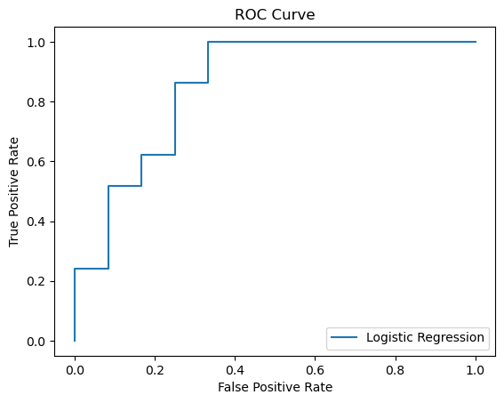

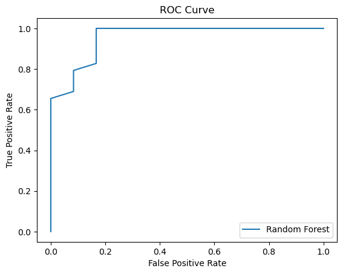

```python
import numpy as np
import pandas as pd
import matplotlib.pyplot as plt
from sklearn.model_selection import GridSearchCV
from sklearn.preprocessing import LabelEncoder
from sklearn.linear_model import LogisticRegression
from sklearn.ensemble import RandomForestClassifier
from sklearn.metrics import accuracy_score, precision_score, recall_score, f1_score, roc_auc_score, roc_curve


## we use the splits from above

# Define parameter grids for grid search
param_grid_rf = {
    'n_estimators': [50], #, 100, 200],
    'max_depth': [None, 10], #, 20],
    'min_samples_split': [2, 5], #, 10],
    'min_samples_leaf': [1, 2] #, 4]
}

param_grid_lr = {
    'C': [0.01, 0.1], #, 1, 10],
    'penalty': [None] #, 'l1', 'l2']
}

# Grid search with cross-validation for Random Forest
rf_grid_search = GridSearchCV(RandomForestClassifier(random_state=42), param_grid_rf, cv=5)
rf_grid_search.fit(X_train, y_train)

# Grid search with cross-validation for Logistic Regression
lr_grid_search = GridSearchCV(LogisticRegression(max_iter=1000, random_state=42), param_grid_lr, cv=5)
lr_grid_search.fit(X_train, y_train)

# Evaluate models
models = {
    'Random Forest': rf_grid_search.best_estimator_,
    'Logistic Regression': lr_grid_search.best_estimator_
}

metrics = {
    'Accuracy': accuracy_score,
    'Precision': precision_score,
    'Recall': recall_score,
    'F1 Score': f1_score,
    'ROC AUC': roc_auc_score
}

# Compute and print metrics for each model
for model_name, model in models.items():
    print(f"Metrics for {model_name}:")
    predictions = model.predict(X_test)
    for metric_name, metric_func in metrics.items():
        if metric_name == 'ROC AUC':
            # For ROC AUC, we need to compute probabilities for positive class
            if hasattr(model, 'predict_proba'):
                y_proba = model.predict_proba(X_test)[:, 1]
                metric_value = metric_func(y_test, y_proba)
            else:
                metric_value = None
        else:
            metric_value = metric_func(y_test, predictions)
        print(f"{metric_name}: {metric_value}")
    print()

# Plot ROC curves for Logistic Regression
if hasattr(models['Logistic Regression'], 'predict_proba'):
    y_proba_lr = models['Logistic Regression'].predict_proba(X_test)[:, 1]
    fpr_lr, tpr_lr, _ = roc_curve(y_test, y_proba_lr)
    plt.plot(fpr_lr, tpr_lr, label='Logistic Regression')
    plt.xlabel('False Positive Rate')
    plt.ylabel('True Positive Rate')
    plt.title('ROC Curve')
    plt.legend()
    plt.show()

# Plot ROC curves for Logistic Regression
if hasattr(models['Random Forest'], 'predict_proba'):
    y_proba_lr = models['Random Forest'].predict_proba(X_test)[:, 1]
    fpr_lr, tpr_lr, _ = roc_curve(y_test, y_proba_lr)
    plt.plot(fpr_lr, tpr_lr, label='Random Forest')
    plt.xlabel('False Positive Rate')
    plt.ylabel('True Positive Rate')
    plt.title('ROC Curve')
    plt.legend()
    plt.show()
```